# CUTe-2 : Classifictaion of Population into Low or High Income Group based on Census Data

Sourjeet

January 12, 2019

# Problem Statement

```
Given Data contains details of various attributes for a population. Based on these
attributes predict whether the individual belongs to low income group or high income
group.
```

# Data Dictionary

```
* age                 : This is a continuous feature that denotes the age of a person.
* working_sector      : This feature shows the type of organization a person is working in. It is a                                 categorical feature and has 7 levels.
* financial_weight    : This feature is a weighted attribute, used to balance the money
* qualification       : Educational qualification
* years_of_education  : number of years of education; continuous variable
* tax paid            : amount of tax paid by the person(continuous variable)
* loan taken          : it is a two level categorical variable defining whether the person has
                        taken loan or no
* marital status      : categorical variable
* occupation          : area of work, a categorical variable with 14 levels
* relationship        : provides relationship status of the employee
* ethnicity           : social background (categorical variable )
* gender              : two level categorical variable
* gain                : it illustrates the financial gain of an person, it is a continuous variable
* loss                : financial loss of the person , it is a continuous variable
* working_hours       : it is a continuous variables describing hours of work of an
                        employee in a week
* country             : describes the origin country of an employee
* target              : Based on the given data your model will have to classify a person into high
                        income / low income.
```

# Coding

## Basic Initializations

### Loading all basic libraries.

```r
library(stats)
library(ggplot2)
library(ggpubr)
library(DMwR)
library(caret)
library(e1071)
library(ROCR)
library(corrplot)
library(vegan)
library(infotheo)
```

Setting the Working Directory

```r
setwd("E:/Workshop/INSOFE/Program/CUTe-2")
getwd()
```

```
## [1] "E:/Workshop/INSOFE/Program/CUTe-2"
```

Reading the data into dataframes.

```r
rawData <- read.csv("train_data.csv")
rawTest <- read.csv("test_data.csv")
cat("Train Data has ", dim(rawData)[1]," rows & ",dim(rawData)[2]," columns.")
```

```
## Train Data has  31587  rows &  18  columns.
```

```r
cat("\nTest Data has ", dim(rawTest)[1]," rows & ",dim(rawTest)[2]," columns.")
```

```
##
## Test Data has  976  rows &  17  columns.
```

```r
attach(rawData)
```

Train Data Structure

```r
str(rawData)
```

```
## 'data.frame':    31587 obs. of  18 variables:
##  $ index             : int  1 2 3 4 5 6 7 8 9 10 ...
##  $ age               : int  39 50 38 53 28 37 49 52 31 42 ...
##  $ working_sector    : Factor w/ 7 levels "local_body","national",..: 6 5 4 4 4 4 4 5 4 4 ...
##  $ financial_weight  : int  77516 83311 215646 234721 338409 284582 160187 209642 45781 159449 ...
##  $ qualification     : Factor w/ 16 levels " 10th"," 11th",..: 10 10 12 2 10 13 7 12 13 10 ...
##  $ years_of_education: int  13 13 9 7 13 14 5 9 14 13 ...
##  $ tax_paid          : num  NA NA NA NA NA ...
##  $ loan_taken        : int  0 0 0 0 0 0 0 1 0 0 ...
##  $ marital_status    : Factor w/ 7 levels "Divorced","Married-civilian",..: 5 2 1 2 2 2 4 2 5 2 ...
##  $ occupation        : Factor w/ 14 levels "cleaner","clerical",..: 2 8 1 1 12 8 9 8 12 8 ...
##  $ relationship      : Factor w/ 6 levels " Husband"," Not-in-family",..: 2 1 2 1 6 6 2 1 2 1 ...
##  $ ethnicity         : Factor w/ 5 levels " Amer-Indian-Eskimo",..: 5 5 5 3 3 5 3 5 5 5 ...
##  $ gender            : Factor w/ 2 levels " Female"," Male": 2 2 2 2 1 1 1 2 1 2 ...
##  $ gain              : int  2174 0 0 0 0 0 0 0 14084 5178 ...
##  $ loss              : int  0 0 0 0 0 0 0 0 0 0 ...
##  $ working_hours     : int  40 13 40 40 40 40 16 45 50 40 ...
##  $ country           : Factor w/ 41 levels " Cambodia"," Canada",..: 39 39 39 39 5 39 23 39 39 39 ...
##  $ target            : int  0 0 0 0 0 0 0 1 1 1 ...
```

Train Data Summary

```r
summary(rawData)
```

```
##      index            age              working_sector  financial_weight
##  Min.   :    1   Min.   :17.00   private      :22033   Min.   :  12285
##  1st Qu.: 7898   1st Qu.:28.00   self_employed: 3543   1st Qu.: 117881
##  Median :15794   Median :37.00   local_body   : 2019   Median : 178564
##  Mean   :15794   Mean   :38.56   state        : 1274   Mean   : 189976
##  3rd Qu.:23691   3rd Qu.:48.00   national     :  923   3rd Qu.: 237466
##  Max.   :31587   Max.   :90.00   (Other)      :   20   Max.   :1484705
##                  NA's   :2       NA's         : 1775   NA's   :2
##        qualification   years_of_education    tax_paid
##   HS-grad     :10198   Min.   : 1.00      Min.   :2010
##   Some-college: 7078   1st Qu.: 9.00      1st Qu.:5004
##   Bachelors   : 5196   Median :10.00      Median :6382
##   Masters     : 1665   Mean   :10.08      Mean   :6286
##   Assoc-voc   : 1336   3rd Qu.:12.00      3rd Qu.:7968
##  (Other)      : 6112   Max.   :16.00      Max.   :9998
##  NA's         :    2                      NA's   :29206
##    loan_taken                   marital_status       occupation
##  Min.   :0.00000   Divorced            : 4299   specialty : 3997
##  1st Qu.:0.00000   Married-civilian    :14540   repair    : 3975
##  Median :0.00000   Married-defence     :   23   managerial: 3943
##  Mean   :0.05024   Married-non-resident:  403   clerical  : 3658
##  3rd Qu.:0.00000   Never-married       :10374   sales     : 3558
##  Max.   :1.00000   Separated           :  987   (Other)   :10674
##                    Widowed             :  961   NA's      : 1782
##           relationship                 ethnicity         gender
##   Husband       :12815    Amer-Indian-Eskimo:  293    Female:10449
##   Not-in-family : 8038    Asian-Pac-Islander: 1004    Male  :21136
##   Other-relative:  952    Black             : 3028   NA's   :    2
##   Own-child     : 4919    Other             :  262
##   Unmarried     : 3340    White             :26998
##   Wife          : 1521   NA's               :    2
##  NA's           :    2
##       gain            loss         working_hours             country
##  Min.   :    0   Min.   :   0.00   Min.   : 1.00    United-States:28295
##  1st Qu.:    0   1st Qu.:   0.00   1st Qu.:40.00    Mexico       :  623
##  Median :    0   Median :   0.00   Median :40.00    Philippines  :  193
##  Mean   : 1090   Mean   :  87.17   Mean   :40.44    Germany      :  133
##  3rd Qu.:    0   3rd Qu.:   0.00   3rd Qu.:45.00    Canada       :  117
##  Max.   :99999   Max.   :4356.00   Max.   :99.00   (Other)       : 1658
##  NA's   :2       NA's   :2         NA's   :2       NA's          :  568
##      target
##  Min.   :0.0000
##  1st Qu.:0.0000
##  Median :0.0000
##  Mean   :0.2412
##  3rd Qu.:0.0000
##  Max.   :1.0000
##
```

Setting the index column for both Train and Test datasets to rownames

```r
rownames(rawData) <- rawData$index
rawData$index = NULL
rownames(rawTest) <- rawTest$index
rawTest$index = NULL
```

## Data Pre-Processing / Analysis

### Dataset level analysis.

Checking the DataSet-wise and Column-wise Null Values

```r
print(" Train Data : ")
```

```
## [1] " Train Data : "
```

```r
sum(is.na(rawData))
```

```
## [1] 33349
```

```r
colSums((is.na(rawData)))
```

```
##                age     working_sector   financial_weight
##                  2               1775                  2
##      qualification years_of_education           tax_paid
##                  2                  0              29206
##         loan_taken     marital_status         occupation
##                  0                  0               1782
##       relationship          ethnicity             gender
##                  2                  2                  2
##               gain               loss      working_hours
##                  2                  2                  2
##            country             target
##                568                  0
```

```r
print(" Test Data : ")
```

```
## [1] " Test Data : "
```

```r
sum(is.na(rawTest))
```

```
## [1] 947
```

```r
colSums((is.na(rawTest)))
```

```
##                age     working_sector   financial_weight
##                  0                 63                  0
##      qualification years_of_education           tax_paid
##                  0                  0                804
##         loan_taken     marital_status         occupation
##                  0                  0                 63
##       relationship          ethnicity             gender
##                  0                  0                  0
##               gain               loss      working_hours
##                  0                  0                  0
##            country
##                 17
```

There are multiple features with the same number of NA values. Checking one of them [Age] to verify if they belong to the same rows.

```r
rawData[is.na(rawData$age),]
```

```
##       age working_sector financial_weight qualification years_of_education
## 31561  NA           <NA>               NA          <NA>                 12
## 31572  NA           <NA>               NA          <NA>                 10
##       tax_paid loan_taken marital_status occupation relationship ethnicity
## 31561       NA          0      Separated       <NA>         <NA>      <NA>
## 31572       NA          0       Divorced       <NA>         <NA>      <NA>
##       gender gain loss working_hours country target
## 31561   <NA>   NA   NA            NA    <NA>      1
## 31572   <NA>   NA   NA            NA    <NA>      1
```

```r
rawData <- rawData[-c(which(is.na(rawData$age))),]
```

Creating a consolidated Data sets out of Train and Test Data.

Assigning a target feature to the Test Data set with default value as 2. This is needed to match the number of features while combining the Train and Test Datasets.

```r
rawTest$target = 2
head(rawTest)
```

```
##       age working_sector financial_weight qualification years_of_education
## 31588  28        private           183175  Some-college                 10
## 31589  29     local_body           115585  Some-college                 10
## 31590  37        private           254202     Bachelors                 13
## 31591  71  self_employed           494223  Some-college                 10
## 31592  27        private           253814       HS-grad                  9
## 31593  40        private           286370       7th-8th                  4
##       tax_paid loan_taken       marital_status occupation   relationship
## 31588 5491.306          1             Divorced   clerical  Not-in-family
## 31589 3456.560          0        Never-married    cleaner  Not-in-family
## 31590 3321.670          0     Married-civilian      sales        Husband
## 31591       NA          0            Separated      sales      Unmarried
## 31592 4840.481          0 Married-non-resident      sales      Unmarried
## 31593 4840.905          0     Married-civilian  inspector        Husband
##       ethnicity  gender gain loss working_hours        country target
## 31588     White  Female    0    0            40  United-States      2
## 31589     White    Male    0    0            50  United-States      2
## 31590     White    Male    0    0            50  United-States      2
## 31591     Black    Male    0 1816             2  United-States      2
## 31592     White  Female    0    0            25  United-States      2
## 31593     White    Male    0    0            40         Mexico      2
```

Combining the Train and Test data sets and cross checking through the dimensions and head/tail.

```r
combinedData <- rbind(rawData,rawTest)
dim(combinedData)
```

```
## [1] 32561    17
```

```r
head(rawData)
```

```
##   age working_sector financial_weight qualification years_of_education
## 1  39          state            77516     Bachelors                 13
## 2  50  self_employed            83311     Bachelors                 13
## 3  38        private           215646       HS-grad                  9
## 4  53        private           234721          11th                  7
## 5  28        private           338409     Bachelors                 13
## 6  37        private           284582       Masters                 14
##   tax_paid loan_taken   marital_status occupation   relationship ethnicity
## 1       NA          0    Never-married   clerical  Not-in-family     White
## 2       NA          0 Married-civilian managerial        Husband     White
## 3       NA          0         Divorced    cleaner  Not-in-family     White
## 4       NA          0 Married-civilian    cleaner        Husband     Black
## 5       NA          0 Married-civilian  specialty           Wife     Black
## 6       NA          0 Married-civilian managerial           Wife     White
##    gender gain loss working_hours        country target
## 1    Male 2174    0            40  United-States      0
## 2    Male    0    0            13  United-States      0
## 3    Male    0    0            40  United-States      0
## 4    Male    0    0            40  United-States      0
## 5  Female    0    0            40           Cuba      0
## 6  Female    0    0            40  United-States      0
```

```r
head(combinedData)
```

```
##   age working_sector financial_weight qualification years_of_education
## 1  39          state            77516     Bachelors                 13
## 2  50  self_employed            83311     Bachelors                 13
## 3  38        private           215646       HS-grad                  9
## 4  53        private           234721          11th                  7
## 5  28        private           338409     Bachelors                 13
## 6  37        private           284582       Masters                 14
##   tax_paid loan_taken   marital_status occupation   relationship ethnicity
## 1       NA          0    Never-married   clerical  Not-in-family     White
## 2       NA          0 Married-civilian managerial        Husband     White
## 3       NA          0         Divorced    cleaner  Not-in-family     White
## 4       NA          0 Married-civilian    cleaner        Husband     Black
## 5       NA          0 Married-civilian  specialty           Wife     Black
## 6       NA          0 Married-civilian managerial           Wife     White
##    gender gain loss working_hours        country target
## 1    Male 2174    0            40  United-States      0
## 2    Male    0    0            13  United-States      0
## 3    Male    0    0            40  United-States      0
## 4    Male    0    0            40  United-States      0
## 5  Female    0    0            40           Cuba      0
## 6  Female    0    0            40  United-States      0
```

```r
tail(combinedData)
```

```
##       age working_sector financial_weight qualification years_of_education
## 32558  51     local_body           203334     Doctorate                 16
## 32559  61  self_employed            50483       7th-8th                  4
## 32560  58     local_body           223214       HS-grad                  9
## 32561  24        private           216984  Some-college                 10
## 32562  50        private           208630       Masters                 14
## 32563  43          state           255835  Some-college                 10
##       tax_paid loan_taken   marital_status occupation    relationship
## 32558       NA          0         Divorced managerial   Not-in-family
## 32559       NA          0 Married-civilian    farming         Husband
## 32560       NA          0 Married-civilian      other         Husband
## 32561       NA          0 Married-civilian      other       Own-child
## 32562       NA          0         Divorced      sales   Not-in-family
## 32563       NA          0         Divorced   clerical  Other-relative
##                 ethnicity  gender gain loss working_hours        country
## 32558               White  Female    0    0            45  United-States
## 32559               White    Male    0    0            56  United-States
## 32560               White    Male    0    0            40  United-States
## 32561  Asian-Pac-Islander  Female    0    0            35  United-States
## 32562               White  Female    0    0            50  United-States
## 32563               White  Female    0    0            40  United-States
##       target
## 32558      2
## 32559      2
## 32560      2
## 32561      2
## 32562      2
## 32563      2
```

```r
tail(rawTest)
```

```
##       age working_sector financial_weight qualification years_of_education
## 32558  51     local_body           203334     Doctorate                 16
## 32559  61  self_employed            50483       7th-8th                  4
## 32560  58     local_body           223214       HS-grad                  9
## 32561  24        private           216984  Some-college                 10
## 32562  50        private           208630       Masters                 14
## 32563  43          state           255835  Some-college                 10
##       tax_paid loan_taken   marital_status occupation    relationship
## 32558       NA          0         Divorced managerial   Not-in-family
## 32559       NA          0 Married-civilian    farming         Husband
## 32560       NA          0 Married-civilian      other         Husband
## 32561       NA          0 Married-civilian      other       Own-child
## 32562       NA          0         Divorced      sales   Not-in-family
## 32563       NA          0         Divorced   clerical  Other-relative
##                 ethnicity  gender gain loss working_hours        country
## 32558               White  Female    0    0            45  United-States
## 32559               White    Male    0    0            56  United-States
## 32560               White    Male    0    0            40  United-States
## 32561  Asian-Pac-Islander  Female    0    0            35  United-States
## 32562               White  Female    0    0            50  United-States
## 32563               White  Female    0    0            40  United-States
##       target
## 32558      2
## 32559      2
## 32560      2
## 32561      2
## 32562      2
## 32563      2
```

```r
combinedData$target=as.factor(combinedData$target)
```

Rechecking on the Null values on the consolidated Dataset.

```r
sum(is.na(combinedData))
```

```
## [1] 34270
```

```r
colSums((is.na(combinedData)))
```

```
##                age     working_sector   financial_weight
##                  0               1836                  0
##      qualification years_of_education           tax_paid
##                  0                  0              30008
##         loan_taken     marital_status         occupation
##                  0                  0               1843
##       relationship          ethnicity             gender
##                  0                  0                  0
##               gain               loss      working_hours
##                  0                  0                  0
##            country             target
##                583                  0
```

Structure of the Consolidated Dataset.

```r
str(combinedData)
```

```
## 'data.frame':    32561 obs. of  17 variables:
##  $ age               : int  39 50 38 53 28 37 49 52 31 42 ...
##  $ working_sector    : Factor w/ 7 levels "local_body","national",..: 6 5 4 4 4 4 4 5 4 4 ...
##  $ financial_weight  : int  77516 83311 215646 234721 338409 284582 160187 209642 45781 159449 ...
##  $ qualification     : Factor w/ 16 levels " 10th"," 11th",..: 10 10 12 2 10 13 7 12 13 10 ...
##  $ years_of_education: int  13 13 9 7 13 14 5 9 14 13 ...
##  $ tax_paid          : num  NA NA NA NA NA ...
##  $ loan_taken        : int  0 0 0 0 0 0 0 1 0 0 ...
##  $ marital_status    : Factor w/ 7 levels "Divorced","Married-civilian",..: 5 2 1 2 2 2 4 2 5 2 ...
##  $ occupation        : Factor w/ 14 levels "cleaner","clerical",..: 2 8 1 1 12 8 9 8 12 8 ...
##  $ relationship      : Factor w/ 6 levels " Husband"," Not-in-family",..: 2 1 2 1 6 6 2 1 2 1 ...
##  $ ethnicity         : Factor w/ 5 levels " Amer-Indian-Eskimo",..: 5 5 5 3 3 5 3 5 5 5 ...
##  $ gender            : Factor w/ 2 levels " Female"," Male": 2 2 2 2 1 1 1 2 1 2 ...
##  $ gain              : int  2174 0 0 0 0 0 0 0 14084 5178 ...
##  $ loss              : int  0 0 0 0 0 0 0 0 0 0 ...
##  $ working_hours     : int  40 13 40 40 40 40 16 45 50 40 ...
##  $ country           : Factor w/ 41 levels " Cambodia"," Canada",..: 39 39 39 39 5 39 23 39 39 39 ...
##  $ target            : Factor w/ 3 levels "0","1","2": 1 1 1 1 1 1 1 2 2 2 ...
```

### Feature level analysis

**Age**

Plotting density plot for the “Age” feature. [only Train Data]

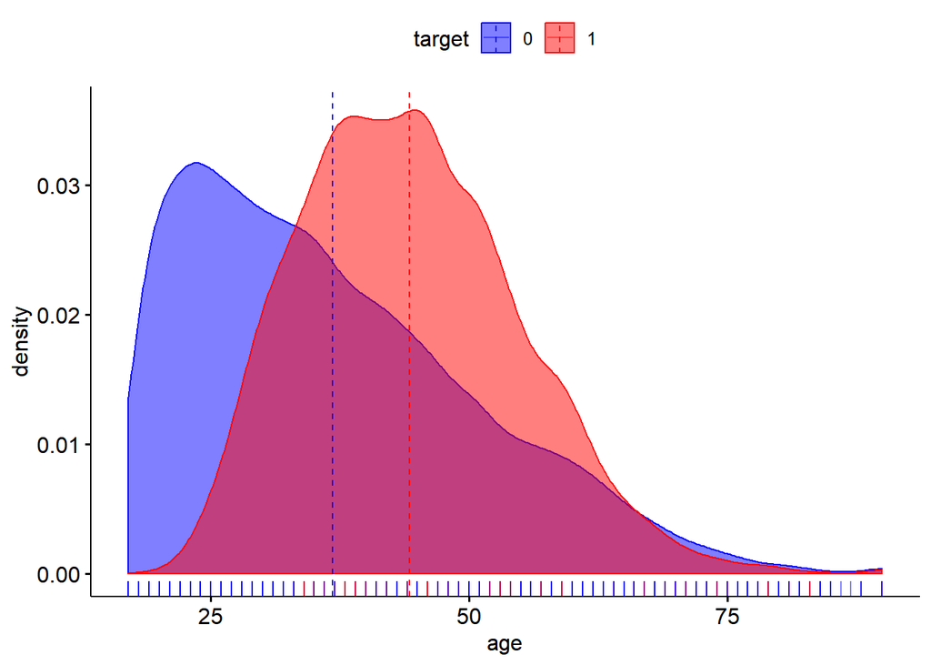

```r
ggdensity(combinedData[combinedData$target != 2,], x = "age",
   add = "mean", rug = TRUE,
   color = "target", fill = "target",
   palette = c("blue", "red"))
```

We can see from the plot above that the age feature is right skewed for target value 0, i.e. Low income group, and close to a normal distribution for value 1, i.e. High Income Group. This shows that people with lesser age are more prone to fall into the low income group, specifically under the age of 35. There is a high density of people between the age of 35 and 60 and belong to the High Income Group. The age group above 70 shows a similar trend among the two income groups.

Below we are binning the age feature as per the above observation.

```r
combinedData$binnedAge = ifelse(combinedData$age <25,0,
                                  ifelse(combinedData$age < 35,1,
                                         ifelse(combinedData$age < 60,2,
                                                ifelse(combinedData$age < 70,3,4))))

combinedData$binnedAge = as.factor(combinedData$binnedAge)
combinedData$age = NULL
str(combinedData)
```

```
## 'data.frame':    32561 obs. of  17 variables:
##  $ working_sector    : Factor w/ 7 levels "local_body","national",..: 6 5 4 4 4 4 4 5 4 4 ...
##  $ financial_weight  : int  77516 83311 215646 234721 338409 284582 160187 209642 45781 159449 ...
##  $ qualification     : Factor w/ 16 levels " 10th"," 11th",..: 10 10 12 2 10 13 7 12 13 10 ...
##  $ years_of_education: int  13 13 9 7 13 14 5 9 14 13 ...
##  $ tax_paid          : num  NA NA NA NA NA ...
##  $ loan_taken        : int  0 0 0 0 0 0 0 1 0 0 ...
##  $ marital_status    : Factor w/ 7 levels "Divorced","Married-civilian",..: 5 2 1 2 2 2 4 2 5 2 ...
##  $ occupation        : Factor w/ 14 levels "cleaner","clerical",..: 2 8 1 1 12 8 9 8 12 8 ...
##  $ relationship      : Factor w/ 6 levels " Husband"," Not-in-family",..: 2 1 2 1 6 6 2 1 2 1 ...
##  $ ethnicity         : Factor w/ 5 levels " Amer-Indian-Eskimo",..: 5 5 5 3 3 5 3 5 5 5 ...
##  $ gender            : Factor w/ 2 levels " Female"," Male": 2 2 2 2 1 1 1 2 1 2 ...
##  $ gain              : int  2174 0 0 0 0 0 0 0 14084 5178 ...
##  $ loss              : int  0 0 0 0 0 0 0 0 0 0 ...
##  $ working_hours     : int  40 13 40 40 40 40 16 45 50 40 ...
##  $ country           : Factor w/ 41 levels " Cambodia"," Canada",..: 39 39 39 39 5 39 23 39 39 39 ...
##  $ target            : Factor w/ 3 levels "0","1","2": 1 1 1 1 1 1 1 2 2 2 ...
##  $ binnedAge         : Factor w/ 5 levels "0","1","2","3",..: 3 3 3 3 2 3 3 3 2 3 ...
```

** Working Sector **

Plotting density plot for the “Working Sector” feature. [only Train Data]

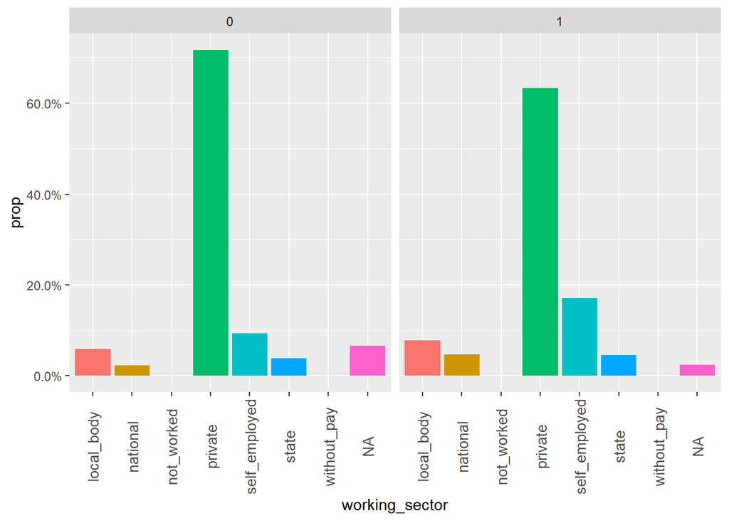

```r
myplot <- ggplot(combinedData[combinedData$target != 2,], aes(working_sector, group = target)) +
          geom_bar(aes(y = ..prop.., fill = factor(..x..)), stat="count") +
          scale_y_continuous(labels=scales::percent) +
          theme( axis.text.x  = element_text(angle=90, vjust=0.5, size=10),legend.position="none") +
          facet_grid(~target)
myplot
```

Performing the below level transformation for the feature according to the above observation. (while making sure that the NA values are not imputed.)

```r
govt <- c("local_body","national","state")
private <- c("private")
self <- c("self_employed")
combinedData$workSector = ifelse(combinedData$working_sector %in% govt, "govt",
                                 ifelse(combinedData$working_sector %in% private, "private",
                                        ifelse(combinedData$working_sector %in% self, "self",
                                               ifelse(is.na(combinedData$working_sector),NA,"other"))))


combinedData$working_sector = NULL
combinedData$workSector = as.factor(combinedData$workSector)
```

** Financial Weight **

Plotting density plot for the “Financial Weight” feature. [only Train Data]

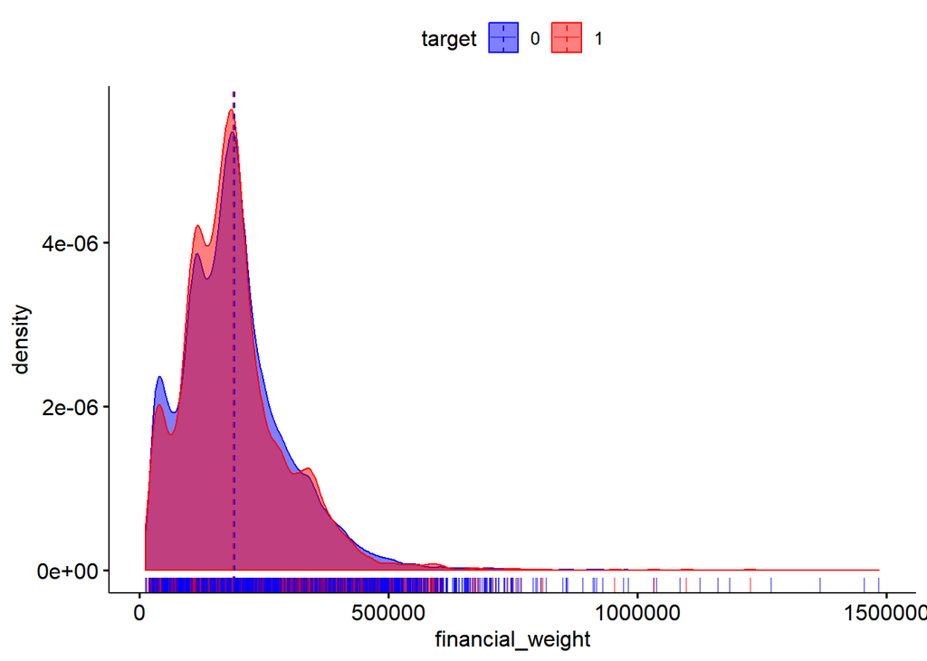

```r
ggdensity(combinedData[combinedData$target != 2,], x = "financial_weight",
   add = "mean", rug = TRUE,
   color = "target", fill = "target",
   palette = c("blue", "red"))
```

Observation : The distribution for this feature is almost same for both the income groups. Infering that this behaviour suggests no variance for this feature accross income groups deciding to drop the feature.

```r
combinedData$financial_weight = NULL
```

** Qualification , Years of Education **

By the look of the data it seems that the two features are very similar in behavior. Confirming the doubt in the below table.

```r
table(combinedData$years_of_education,combinedData$qualification)
```

```
##
##       10th  11th  12th  1st-4th  5th-6th  7th-8th   9th  Assoc-acdm
##   1      0     0     0        0        0        0     0           0
##   2      0     0     0      168        0        0     0           0
##   3      0     0     0        0      333        0     0           0
##   4      0     0     0        0        0      646     0           0
##   5      0     0     0        0        0        0   514           0
##   6    933     0     0        0        0        0     0           0
##   7      0  1175     0        0        0        0     0           0
##   8      0     0   433        0        0        0     0           0
##   9      0     0     0        0        0        0     0           0
##   10     0     0     0        0        0        0     0           0
##   11     0     0     0        0        0        0     0           0
##   12     0     0     0        0        0        0     0        1067
##   13     0     0     0        0        0        0     0           0
```

[output cut: 39 more lines]

From the above table we can infer that these two features have a one-to-one mapping. We can safely drop one of the features. In facvouring of keeping the readability/interpretability of the data, choosing to drop the “Years of Education” feature.

```r
combinedData$years_of_education = NULL
```

Plotting density plot for the “Qualification” feature. [only Train Data]

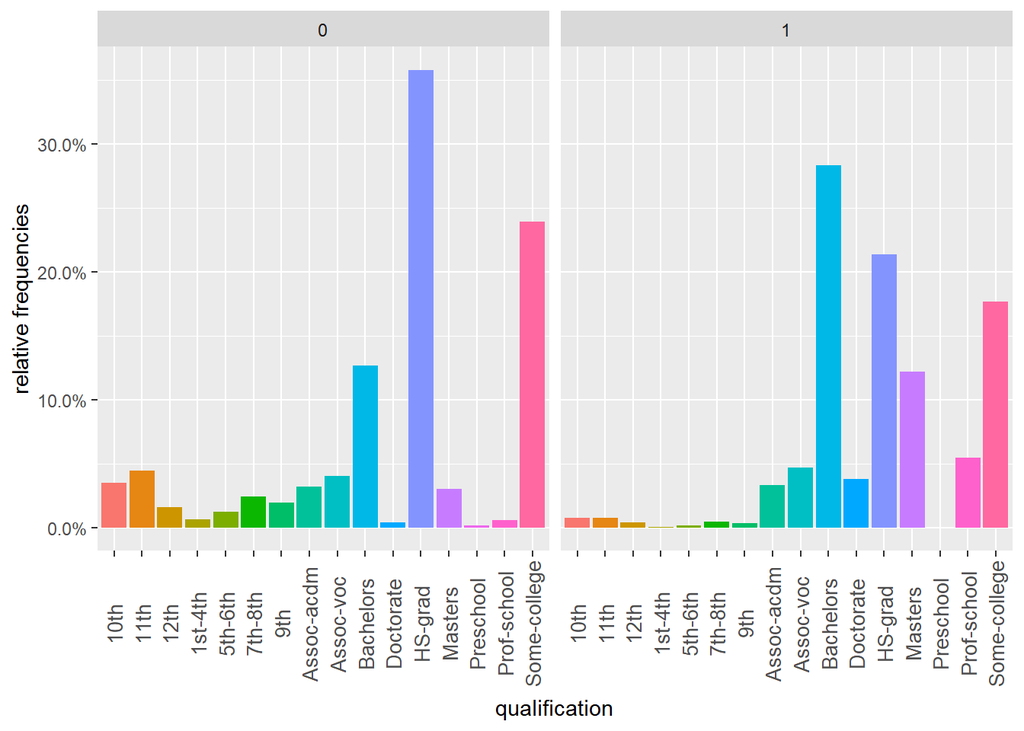

```r
myplot <- ggplot(combinedData[combinedData$target != 2,], aes(qualification, group = target)) +
          geom_bar(aes(y = ..prop.., fill = factor(..x..)), stat="count") +
          scale_y_continuous(labels=scales::percent) +
          theme( axis.text.x  = element_text(angle=90, vjust=0.5, size=10),legend.position="none") +
          ylab("relative frequencies") +
          facet_grid(~target)
myplot
```

Re-levelling the data based on the feature meaning and above plots

```r
levels(combinedData$qualification)
```

```
##  [1] " 10th"         " 11th"         " 12th"         " 1st-4th"
##  [5] " 5th-6th"      " 7th-8th"      " 9th"          " Assoc-acdm"
##  [9] " Assoc-voc"    " Bachelors"    " Doctorate"    " HS-grad"
## [13] " Masters"      " Preschool"    " Prof-school"  " Some-college"
```

```r
school = c(" 10th"," 11th"," 12th"," 1st-4th"," 5th-6th"," 7th-8th"," 9th"," Preschool")
inClg  = c(" HS-grad"," Some-college"," Assoc-acdm"," Assoc-voc")
postGrad = c(" Doctorate"," Prof-school"," Masters")

combinedData$EduQual = ifelse(combinedData$qualification %in% school,"school",
                                  ifelse(combinedData$qualification %in% inClg,"inClg",
                                         ifelse(combinedData$qualification %in% postGrad, "postGrad","grad")))
combinedData$qualification = NULL
combinedData$EduQual = as.factor(combinedData$EduQual)
```

```r
sum(is.na(combinedData))
```

```
## [1] 34270
```

```r
colSums((is.na(combinedData)))
```

```
##       tax_paid     loan_taken marital_status     occupation   relationship
##          30008              0              0           1843              0
##      ethnicity         gender           gain           loss  working_hours
##              0              0              0              0              0
##        country         target      binnedAge     workSector        EduQual
##            583              0              0           1836              0
```

```r
combinedData$tax_paid = NULL
```

** Loan taken **

Plotting density plot for the “Loan Taken” feature. [only Train Data]

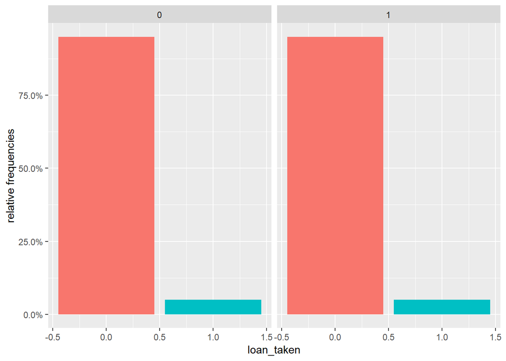

```r
myplot <- ggplot(combinedData[combinedData$target != 2,], aes(loan_taken, group = target)) +
          geom_bar(aes(y = ..prop.., fill = factor(..x..)), stat="count") +
          scale_y_continuous(labels=scales::percent) +
          theme(legend.position="none") +
          ylab("relative frequencies") +
          facet_grid(~target)
myplot
```

Observation : Very similar relative distribution. Dropping the feature.

```r
combinedData$loan_taken = NULL
```

** Marital Status **

Plotting density plot for the “Marital Status” feature. [only Train Data]

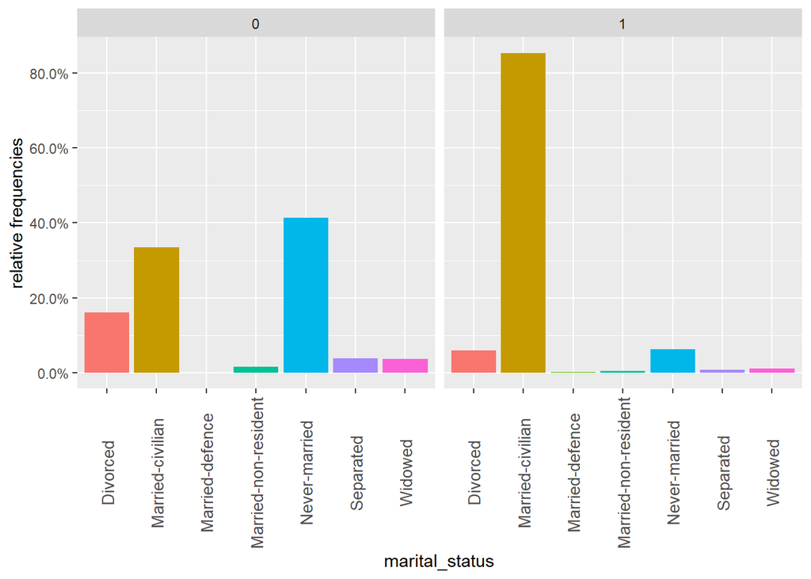

```r
myplot <- ggplot(combinedData[combinedData$target != 2,], aes(marital_status, group = target)) +
          geom_bar(aes(y = ..prop.., fill = factor(..x..)), stat="count") +
          scale_y_continuous(labels=scales::percent) +
          theme( axis.text.x  = element_text(angle=90, vjust=0.5, size=10),legend.position="none") +
          ylab("relative frequencies") +
          facet_grid(~target)
myplot
```

Observation : This feature can be broadly interpreted as whether the person is living alone or has a partner, considering the predominant nuclear families we see in the US. So relevelling the feature accordingly.

```r
combinedData$stayStatus = ifelse(combinedData$marital_status %in%  c("Divorced","Never-married","Seperated","Widowed","Married-non-resident"), "Alone" , "withSpouse")
combinedData$marital_status = NULL
combinedData$stayStatus = as.factor(combinedData$stayStatus)
str(combinedData)
```

```
## 'data.frame':    32561 obs. of  13 variables:
##  $ occupation   : Factor w/ 14 levels "cleaner","clerical",..: 2 8 1 1 12 8 9 8 12 8 ...
##  $ relationship : Factor w/ 6 levels " Husband"," Not-in-family",..: 2 1 2 1 6 6 2 1 2 1 ...
##  $ ethnicity    : Factor w/ 5 levels " Amer-Indian-Eskimo",..: 5 5 5 3 3 5 3 5 5 5 ...
##  $ gender       : Factor w/ 2 levels " Female"," Male": 2 2 2 2 1 1 1 2 1 2 ...
##  $ gain         : int  2174 0 0 0 0 0 0 0 14084 5178 ...
##  $ loss         : int  0 0 0 0 0 0 0 0 0 0 ...
##  $ working_hours: int  40 13 40 40 40 40 16 45 50 40 ...
##  $ country      : Factor w/ 41 levels " Cambodia"," Canada",..: 39 39 39 39 5 39 23 39 39 39 ...
##  $ target       : Factor w/ 3 levels "0","1","2": 1 1 1 1 1 1 1 2 2 2 ...
##  $ binnedAge    : Factor w/ 5 levels "0","1","2","3",..: 3 3 3 3 2 3 3 3 2 3 ...
##  $ workSector   : Factor w/ 4 levels "govt","other",..: 1 4 3 3 3 3 3 4 3 3 ...
##  $ EduQual      : Factor w/ 4 levels "grad","inClg",..: 1 1 2 4 1 3 4 2 3 1 ...
##  $ stayStatus   : Factor w/ 2 levels "Alone","withSpouse": 1 2 1 2 2 2 1 2 1 2 ...
```

** Occupation **

Plotting density plot for the “Occupation” feature. [only Train Data]

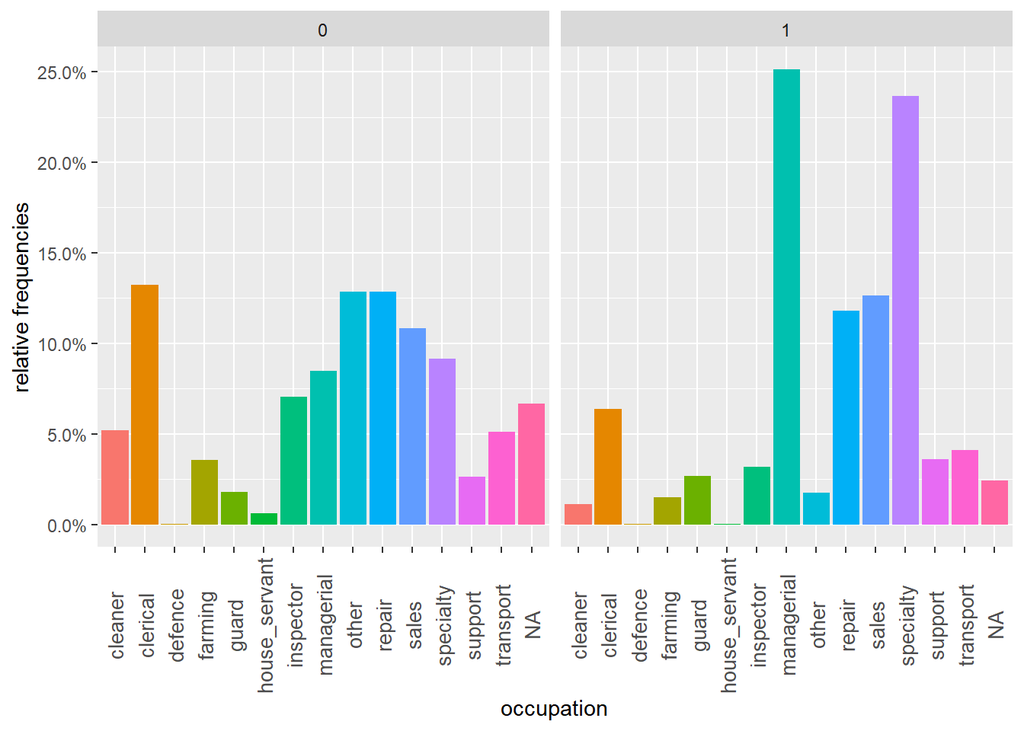

```r
myplot <- ggplot(combinedData[combinedData$target != 2,], aes(occupation, group = target)) +
          geom_bar(aes(y = ..prop.., fill = factor(..x..)), stat="count") +
          scale_y_continuous(labels=scales::percent) +
          theme( axis.text.x  = element_text(angle=90, vjust=0.5, size=10),legend.position="none") +
          ylab("relative frequencies") +
          facet_grid(~target)
myplot
```

```r
table(combinedData$occupation)
```

```
##
##       cleaner      clerical       defence       farming         guard
##          1370          3770             9           994           649
## house_servant     inspector    managerial         other        repair
##           149          2002          4066          3295          4099
##         sales     specialty       support     transport
##          3650          4140           928          1597
```

```r
highSkill = c("clerical","managerial","sales","speciality","support")
medSkill = c("cleaner","farming","guard","house_servant","repair","transport")
security = c("defence","inspector")
combinedData$occuType <- ifelse(combinedData$occupation %in% highSkill, "highskill",
                                ifelse(combinedData$occupation %in% medSkill, "medSkill",
                                       ifelse(combinedData$occupation %in% security, "security",
                                              ifelse(is.na(combinedData$occupation),NA,"other"))))

combinedData$occuType = as.factor(combinedData$occuType)
combinedData$occupation = NULL
str(combinedData)
```

```
## 'data.frame':    32561 obs. of  13 variables:
##  $ relationship : Factor w/ 6 levels " Husband"," Not-in-family",..: 2 1 2 1 6 6 2 1 2 1 ...
##  $ ethnicity    : Factor w/ 5 levels " Amer-Indian-Eskimo",..: 5 5 5 3 3 5 3 5 5 5 ...
##  $ gender       : Factor w/ 2 levels " Female"," Male": 2 2 2 2 1 1 1 2 1 2 ...
##  $ gain         : int  2174 0 0 0 0 0 0 0 14084 5178 ...
##  $ loss         : int  0 0 0 0 0 0 0 0 0 0 ...
##  $ working_hours: int  40 13 40 40 40 40 16 45 50 40 ...
##  $ country      : Factor w/ 41 levels " Cambodia"," Canada",..: 39 39 39 39 5 39 23 39 39 39 ...
##  $ target       : Factor w/ 3 levels "0","1","2": 1 1 1 1 1 1 1 2 2 2 ...
##  $ binnedAge    : Factor w/ 5 levels "0","1","2","3",..: 3 3 3 3 2 3 3 3 2 3 ...
##  $ workSector   : Factor w/ 4 levels "govt","other",..: 1 4 3 3 3 3 3 4 3 3 ...
##  $ EduQual      : Factor w/ 4 levels "grad","inClg",..: 1 1 2 4 1 3 4 2 3 1 ...
##  $ stayStatus   : Factor w/ 2 levels "Alone","withSpouse": 1 2 1 2 2 2 1 2 1 2 ...
##  $ occuType     : Factor w/ 4 levels "highskill","medSkill",..: 1 1 2 2 3 1 3 1 3 1 ...
```

** Relationship **

Plotting density plot for the “Relationship” feature. [only Train Data]

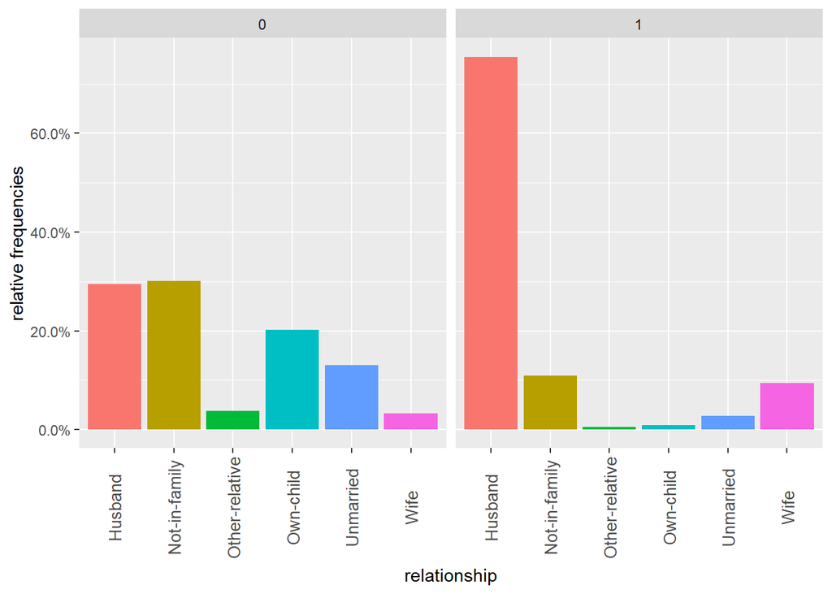

```r
myplot <- ggplot(combinedData[combinedData$target != 2,], aes(relationship, group = target)) +
          geom_bar(aes(y = ..prop.., fill = factor(..x..)), stat="count") +
          scale_y_continuous(labels=scales::percent) +
          theme( axis.text.x  = element_text(angle=90, vjust=0.5, size=10),legend.position="none") +
          ylab("relative frequencies") +
          facet_grid(~target)
myplot
```

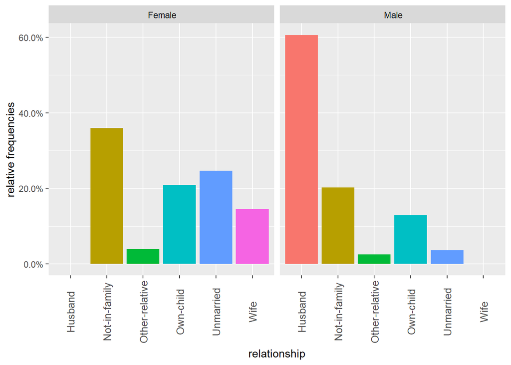

```r
myplot <- ggplot(combinedData[combinedData$target != 2,], aes(relationship, group = gender)) +
          geom_bar(aes(y = ..prop.., fill = factor(..x..)), stat="count") +
          scale_y_continuous(labels=scales::percent) +
          theme( axis.text.x  = element_text(angle=90, vjust=0.5, size=10),legend.position="none") +
          ylab("relative frequencies") +
          facet_grid(~gender)
myplot
```

```r
combinedData$relationship = NULL
```

** Ethnicity **

Plotting density plot for the “ethnicity” feature. [only Train Data]

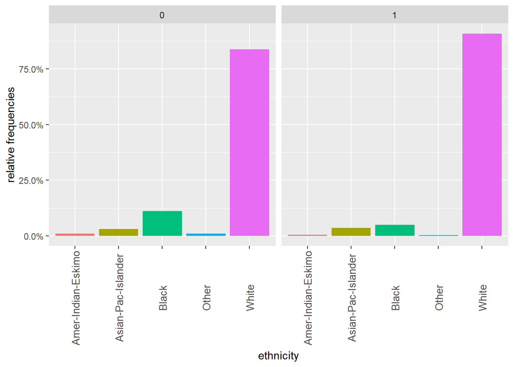

```r
myplot <- ggplot(combinedData[combinedData$target != 2,], aes(ethnicity, group = target)) +
          geom_bar(aes(y = ..prop.., fill = factor(..x..)), stat="count") +
          scale_y_continuous(labels=scales::percent) +
          theme( axis.text.x  = element_text(angle=90, vjust=0.5, size=10),legend.position="none") +
          ylab("relative frequencies") +
          facet_grid(~target)
myplot
```

```r
combinedData$ethnicity <- ifelse(combinedData$ethnicity == " White", "White","Other")

combinedData$ethnicity = as.factor(combinedData$ethnicity)
str(combinedData)
```

```
## 'data.frame':    32561 obs. of  12 variables:
##  $ ethnicity    : Factor w/ 2 levels "Other","White": 2 2 2 1 1 2 1 2 2 2 ...
##  $ gender       : Factor w/ 2 levels " Female"," Male": 2 2 2 2 1 1 1 2 1 2 ...
##  $ gain         : int  2174 0 0 0 0 0 0 0 14084 5178 ...
##  $ loss         : int  0 0 0 0 0 0 0 0 0 0 ...
##  $ working_hours: int  40 13 40 40 40 40 16 45 50 40 ...
##  $ country      : Factor w/ 41 levels " Cambodia"," Canada",..: 39 39 39 39 5 39 23 39 39 39 ...
##  $ target       : Factor w/ 3 levels "0","1","2": 1 1 1 1 1 1 1 2 2 2 ...
##  $ binnedAge    : Factor w/ 5 levels "0","1","2","3",..: 3 3 3 3 2 3 3 3 2 3 ...
##  $ workSector   : Factor w/ 4 levels "govt","other",..: 1 4 3 3 3 3 3 4 3 3 ...
##  $ EduQual      : Factor w/ 4 levels "grad","inClg",..: 1 1 2 4 1 3 4 2 3 1 ...
##  $ stayStatus   : Factor w/ 2 levels "Alone","withSpouse": 1 2 1 2 2 2 1 2 1 2 ...
##  $ occuType     : Factor w/ 4 levels "highskill","medSkill",..: 1 1 2 2 3 1 3 1 3 1 ...
```

** Gender **

Plotting density plot for the “gender” feature. [only Train Data]

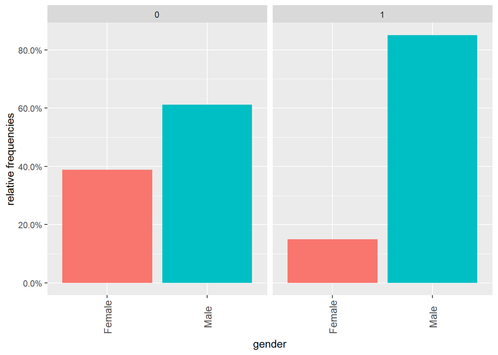

```r
myplot <- ggplot(combinedData[combinedData$target != 2,], aes(gender, group = target)) +
          geom_bar(aes(y = ..prop.., fill = factor(..x..)), stat="count") +
          scale_y_continuous(labels=scales::percent) +
          theme( axis.text.x  = element_text(angle=90, vjust=0.5, size=10),legend.position="none") +
          ylab("relative frequencies") +
          facet_grid(~target)
myplot
```

```r
combinedData$hasGained = combinedData$gain - combinedData$loss
combinedData$hasGained = ifelse(combinedData$hasGained >0,1,
                                 ifelse(combinedData$hasGained <0,-1, 0))
combinedData$hasGained = as.factor(combinedData$hasGained)
combinedData$loss = NULL
combinedData$gain = NULL
```

** Gain / Loss **

Plotting density plot for the “Gain / Loss” features. [only Train Data]

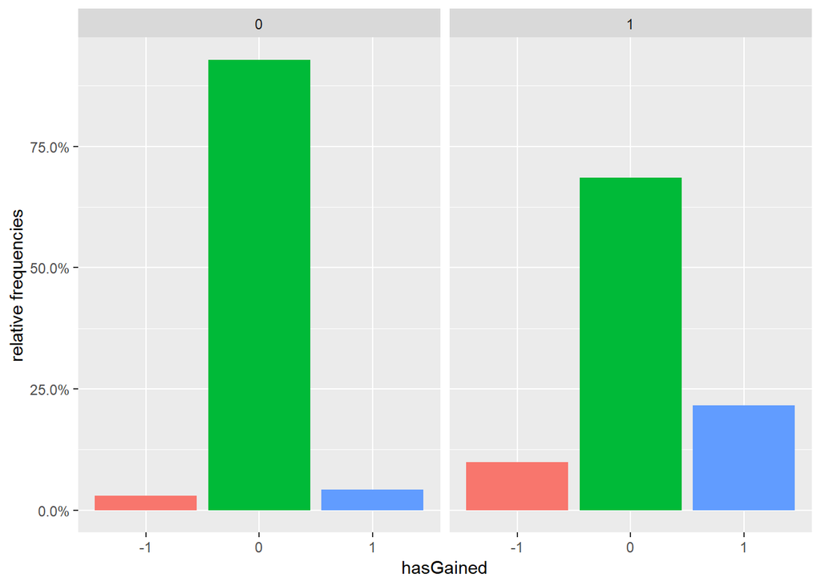

```r
myplot <- ggplot(combinedData[combinedData$target != 2,], aes(hasGained, group = target)) +
          geom_bar(aes(y = ..prop.., fill = factor(..x..)), stat="count") +
          scale_y_continuous(labels=scales::percent) +
          theme(legend.position="none") +
          ylab("relative frequencies") +
          facet_grid(~target)
myplot
```

** Working Hours **

Plotting density plot for the “Working Hours” feature. [only Train Data]

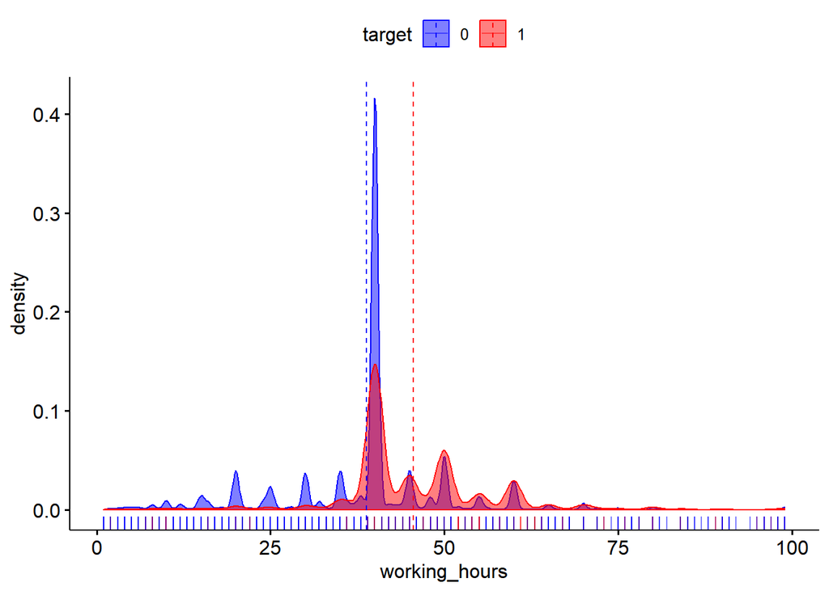

```r
ggdensity(combinedData[combinedData$target != 2,], x = "working_hours",
   add = "mean", rug = TRUE,
   color = "target", fill = "target",
   palette = c("blue", "red"))
```

```r
combinedData$WorkHr = ifelse(combinedData$working_hours <36,0,
                                  ifelse(combinedData$working_hours > 41,2,1))

combinedData$WorkHr = as.factor(combinedData$WorkHr)
combinedData$working_hours = NULL
str(combinedData)
```

```
## 'data.frame':    32561 obs. of  11 variables:
##  $ ethnicity : Factor w/ 2 levels "Other","White": 2 2 2 1 1 2 1 2 2 2 ...
##  $ gender    : Factor w/ 2 levels " Female"," Male": 2 2 2 2 1 1 1 2 1 2 ...
##  $ country   : Factor w/ 41 levels " Cambodia"," Canada",..: 39 39 39 39 5 39 23 39 39 39 ...
##  $ target    : Factor w/ 3 levels "0","1","2": 1 1 1 1 1 1 1 2 2 2 ...
##  $ binnedAge : Factor w/ 5 levels "0","1","2","3",..: 3 3 3 3 2 3 3 3 2 3 ...
##  $ workSector: Factor w/ 4 levels "govt","other",..: 1 4 3 3 3 3 3 4 3 3 ...
##  $ EduQual   : Factor w/ 4 levels "grad","inClg",..: 1 1 2 4 1 3 4 2 3 1 ...
##  $ stayStatus: Factor w/ 2 levels "Alone","withSpouse": 1 2 1 2 2 2 1 2 1 2 ...
##  $ occuType  : Factor w/ 4 levels "highskill","medSkill",..: 1 1 2 2 3 1 3 1 3 1 ...
##  $ hasGained : Factor w/ 3 levels "-1","0","1": 3 2 2 2 2 2 2 2 3 3 ...
##  $ WorkHr    : Factor w/ 3 levels "0","1","2": 2 1 2 2 2 2 1 3 3 2 ...
```

** Country **

Plotting density plot for the “Country” feature. [only Train Data]

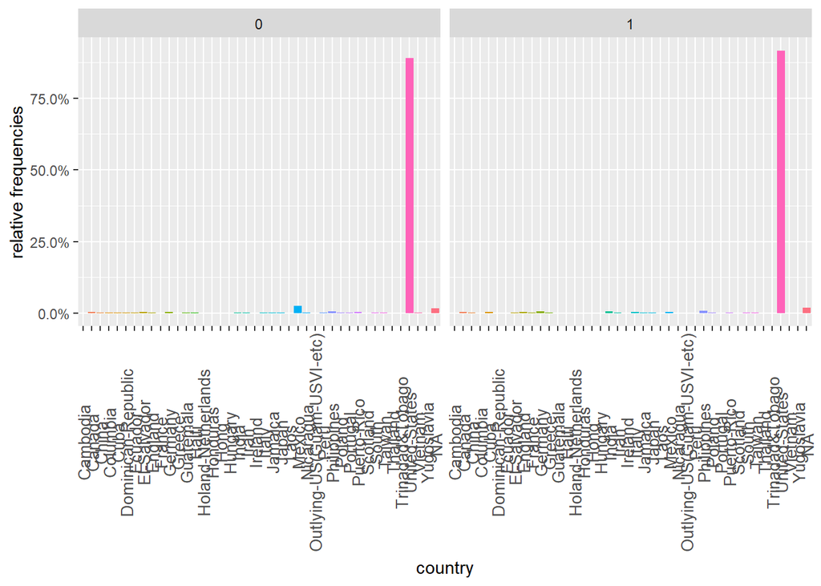

```r
myplot <- ggplot(combinedData[combinedData$target != 2,], aes(country, group = target)) +
          geom_bar(aes(y = ..prop.., fill = factor(..x..)), stat="count") +
          scale_y_continuous(labels=scales::percent) +
          theme( axis.text.x  = element_text(angle=90, vjust=0.5, size=10),legend.position="none") +
          ylab("relative frequencies") +
          facet_grid(~target)
myplot
```

```r
combinedData$country <- ifelse(combinedData$country == " United-States", "USA",
                               ifelse(is.na(combinedData$country),NA,"Other"))

combinedData$country = as.factor(combinedData$country)
str(combinedData)
```

```
## 'data.frame':    32561 obs. of  11 variables:
##  $ ethnicity : Factor w/ 2 levels "Other","White": 2 2 2 1 1 2 1 2 2 2 ...
##  $ gender    : Factor w/ 2 levels " Female"," Male": 2 2 2 2 1 1 1 2 1 2 ...
##  $ country   : Factor w/ 2 levels "Other","USA": 2 2 2 2 1 2 1 2 2 2 ...
##  $ target    : Factor w/ 3 levels "0","1","2": 1 1 1 1 1 1 1 2 2 2 ...
##  $ binnedAge : Factor w/ 5 levels "0","1","2","3",..: 3 3 3 3 2 3 3 3 2 3 ...
##  $ workSector: Factor w/ 4 levels "govt","other",..: 1 4 3 3 3 3 3 4 3 3 ...
##  $ EduQual   : Factor w/ 4 levels "grad","inClg",..: 1 1 2 4 1 3 4 2 3 1 ...
##  $ stayStatus: Factor w/ 2 levels "Alone","withSpouse": 1 2 1 2 2 2 1 2 1 2 ...
##  $ occuType  : Factor w/ 4 levels "highskill","medSkill",..: 1 1 2 2 3 1 3 1 3 1 ...
##  $ hasGained : Factor w/ 3 levels "-1","0","1": 3 2 2 2 2 2 2 2 3 3 ...
##  $ WorkHr    : Factor w/ 3 levels "0","1","2": 2 1 2 2 2 2 1 3 3 2 ...
```

```r
sum(is.na(combinedData))
```

```
## [1] 4262
```

```r
colSums((is.na(combinedData)))
```

```
##  ethnicity     gender    country     target  binnedAge workSector
##          0          0        583          0          0       1836
##    EduQual stayStatus   occuType  hasGained     WorkHr
##          0          0       1843          0          0
```

```r
cobinedData_dependent <- combinedData
combinedData_target <- combinedData$target
cobinedData_dependent$target = NULL
```

```r
head(cobinedData_dependent)
```

```
##   ethnicity  gender country binnedAge workSector  EduQual stayStatus
## 1     White    Male     USA         2       govt     grad      Alone
## 2     White    Male     USA         2       self     grad withSpouse
## 3     White    Male     USA         2    private    inClg      Alone
## 4     Other    Male     USA         2    private   school withSpouse
## 5     Other  Female   Other         1    private     grad withSpouse
## 6     White  Female     USA         2    private postGrad withSpouse
##    occuType hasGained WorkHr
## 1 highskill         1      1
## 2 highskill         0      0
## 3  medSkill         0      1
## 4  medSkill         0      1
## 5     other         0      1
## 6 highskill         0      1
```

```r
cobinedData_dependent=knnImputation(cobinedData_dependent,k=10,scale=T,meth="weighAvg")
sum(is.na(cobinedData_dependent))
```

```
## [1] 0
```

```r
imputedCombines <- data.frame(cobinedData_dependent,combinedData_target)
names(imputedCombines)[names(imputedCombines) == "combinedData_target"] <- "target"
head(imputedCombines)
```

```
##   ethnicity  gender country binnedAge workSector  EduQual stayStatus
## 1     White    Male     USA         2       govt     grad      Alone
## 2     White    Male     USA         2       self     grad withSpouse
## 3     White    Male     USA         2    private    inClg      Alone
## 4     Other    Male     USA         2    private   school withSpouse
## 5     Other  Female   Other         1    private     grad withSpouse
## 6     White  Female     USA         2    private postGrad withSpouse
##    occuType hasGained WorkHr target
## 1 highskill         1      1      0
## 2 highskill         0      0      0
## 3  medSkill         0      1      0
## 4  medSkill         0      1      0
## 5     other         0      1      0
## 6 highskill         0      1      0
```

```r
tail(imputedCombines)
```

```
##       ethnicity  gender country binnedAge workSector  EduQual stayStatus
## 32558     White  Female     USA         2       govt postGrad      Alone
## 32559     White    Male     USA         3       self   school withSpouse
## 32560     White    Male     USA         2       govt    inClg withSpouse
## 32561     Other  Female     USA         0    private    inClg withSpouse
## 32562     White  Female     USA         2    private postGrad      Alone
## 32563     White  Female     USA         2       govt    inClg      Alone
##        occuType hasGained WorkHr target
## 32558 highskill         0      2      2
## 32559  medSkill         0      2      2
## 32560     other         0      1      2
## 32561     other         0      0      2
## 32562 highskill         0      2      2
## 32563 highskill         0      1      2
```

```r
finalTestData <- imputedCombines[c(which(imputedCombines$target == 2)),]
finalData <- imputedCombines[c(which(imputedCombines$target != 2)),]
finalData$target = droplevels(finalData$target)

finalTestData$target = NULL
dim(finalTestData)
```

```
## [1] 976  10
```

```r
dim(finalData)
```

```
## [1] 31585    11
```

```r
set.seed(786)
folds <- createFolds(factor(finalData$target), k = 5, list = FALSE)
```

### Manually creating 5 folds to do K-Fold cross validation on the train data

```r
nbSensitivity = 0
nbSpecificity = 0
nbBalAccuracy = 0
nbAccuracy    = 0

lrSensitivity = 0
lrSpecificity = 0
lrBalAccuracy = 0
lrAccuracy    = 0

for(i in 1:5){
  dataTest  <- finalData[folds == i,]
  dataTrain <- finalData[folds != i,]
  testTarget_act <- dataTest$target
  dataTest$target = NULL

  nbModel       <- naiveBayes(dataTrain$target~., dataTrain)
  nbPrediction  <- predict(nbModel, dataTest)
  nbConfMat     <- confusionMatrix(data = nbPrediction, reference = testTarget_act)

  nbSensitivity = nbSensitivity + nbConfMat$table[1,1]/(nbConfMat$table[1,1] + nbConfMat$table[2,1])
  nbSpecificity = nbSpecificity + nbConfMat$table[2,2]/(nbConfMat$table[1,2] + nbConfMat$table[2,2])
  nbAccuracy    = nbAccuracy    + (nbConfMat$table[1,1] + nbConfMat$table[2,2])/sum(nbConfMat$table)


  lrModel       <- glm(target ~ ., data = dataTrain, family=binomial)
  lrProbability <- predict(lrModel, dataTest, type = "response")
  lrPrediction  <- ifelse(lrProbability <= 0.40, 0, 1)
  lrConfMat     <- confusionMatrix(data = as.factor(lrPrediction), reference = testTarget_act)

  lrSensitivity = lrSensitivity + lrConfMat$table[1,1]/(lrConfMat$table[1,1] + lrConfMat$table[2,1])
  lrSpecificity = lrSpecificity + lrConfMat$table[2,2]/(lrConfMat$table[1,2] + lrConfMat$table[2,2])
  lrAccuracy    = lrAccuracy    + (lrConfMat$table[1,1] + lrConfMat$table[2,2])/sum(lrConfMat$table)

}

nbBalAccuracy = ((nbSensitivity/5)+(nbSpecificity/5))/2
lrBalAccuracy = ((lrSensitivity/5)+(lrSpecificity/5))/2
```

```r
cat(" Naive Bayes Statistics ")
```

```
##  Naive Bayes Statistics
```

```r
cat("\n\n Average Accuracy          : ",nbAccuracy/5)
```

```
##
##
##  Average Accuracy          :  0.8234919
```

```r
cat("\n Average Sensitivity       : ",nbSensitivity/5)
```

```
##
##  Average Sensitivity       :  0.882009
```

```r
cat("\n Average Specificity       : ",nbSpecificity/5)
```

```
##
##  Average Specificity       :  0.6393578
```

```r
cat("\n Average Balanced Accuracy : ",nbBalAccuracy)
```

```
##
##  Average Balanced Accuracy :  0.7606834
```

```r
cat("\n\n Logistic Regression ")
```

```
##
##
##  Logistic Regression
```

```r
cat("\n\n Average Accuracy          : ",lrAccuracy/5)
```

```
##
##
##  Average Accuracy          :  0.8319454
```

```r
cat("\n Average Sensitivity       : ",lrSensitivity/5)
```

```
##
##  Average Sensitivity       :  0.8890599
```

```r
cat("\n Average Specificity       : ",lrSpecificity/5)
```

```
##
##  Average Specificity       :  0.6522228
```

```r
cat("\n Average Balanced Accuracy : ",lrBalAccuracy)
```

```
##
##  Average Balanced Accuracy :  0.7706414
```

```r
dim(finalTestData)
```

```
## [1] 976  10
```

```r
dim(finalData)
```

```
## [1] 31585    11
```

```r
model_NB <- naiveBayes(finalData$target~., finalData)
nbFinalPrediction <- data.frame("target" = as.factor(predict(model_NB, finalTestData)))

nbSubmission <- data.frame("index" = rownames(finalTestData),nbFinalPrediction)
head(nbSubmission)
```

```
##   index target
## 1 31588      0
## 2 31589      0
## 3 31590      1
## 4 31591      0
## 5 31592      0
## 6 31593      0
```

```r
model_LR <- glm(target ~ ., data = finalData, family=binomial)
lrFinalProbability <- predict(lrModel, finalTestData, type = "response")
lrFinaelPrediction  <- as.factor(ifelse(lrFinalProbability <= 0.35, 0, 1))

lrSubmission <- data.frame("index" = rownames(finalTestData),"target" = lrFinaelPrediction)
head(lrSubmission)
```

```
##       index target
## 31588 31588      0
## 31589 31589      0
## 31590 31590      1
## 31591 31591      0
## 31592 31592      0
## 31593 31593      0
```

```r
write.csv(x = nbSubmission, file = "NBsubmission10.csv",row.names = F)
write.csv(x = lrSubmission, file = "LRsubmission10.csv",row.names = F)
```